# BCB420 - Computational Systems Biology

A2: Differential Gene Expression and Preliminary ORA

Chloe Nichole Calica

# 1 Introduction

Previously in Assignment 1, the RNA-seq dataset with accession GSE194294, referred to as the **Bb RNAseq dataset** moving forward, was explored, pre-processed, and normalized in preparation for differential expression (DE) analysis which will be performed in this assignment.

## 1.1 Dataset Summary

In brief, the Bb RNAseq dataset investigates how exposure to *Borrelia burgdorferi*, the bacterium responsible for Lyme disease, affects gene expression and DNA methylation in human cells [1]. The experimental design used to obtain this dataset consisted of 12 samples that had one control and one condition for each cell line with three replicates each. The cell lines were HUVEC (human umbilical vein endothelial cells) and HEK-931 (human embryonic kidney cells) with the control being these cells incubated in pure growth medium while the condition was growing these cells with *B. burgdorefri strain B31* fror about a 72 hour exposure.

## 1.3 Normalization

After pre-processing the dataset, it underwent normalization through TMM (Trimmed Mean of M-values) using the *edgeR* [2] package. This normalization method was chosen because it accounts for library size differences without forcing distributions to be identical i.e. it normalizes RNA-seq data while preserving meaningful biological variation which is what we want for the DE analysis. Once the normalization has been applied to the dataset, the density plot shows the distribution being smoothed out across all samples, indicating that the distributions have tightened and making the samples more comparable against each other. The boxplots, on the other hand, show that the median for all samples were lined up in the median line. Additionally, the normalized dataset was assessed for outliers, saaple separation by MDS, and dispersion through a BCV plot. No outliers were excluded from the normalized dataset akin to the original publication methods. MDS plot based on treatment (*B. burgdorferi exposure* vs. unexposed) shows better separation of conditions wherein similar treatments cluster together. This observation suggests that treatment effect is more dominant that cell type effects which indicate that the cell lines may have to be analyzed separately in downstream analysis. Lastly, the normalized dataset was confirmed to be following a negative-binomial model, concluding that NB model assumptions hold for high-expression genes.

## 1.5 Final Normalized Dataset

After all the pre-processing performed in the initial dataset, the final normalized matrix had 16497 mapped genes with an overall coverage of 1.2 million counts for the HUVEC samples while 800k counts for the HEK293 samples.

# 2 Load Libraries Used

```r
library(edgeR)
library(knitr)
library(ComplexHeatmap)
library(circlize)
library(ggplot2)
library(gridExtra)
library(gprofiler2)
```

# 3 Differential Expression

In this section, we obtain the differentially expressed genes between cell lines that are exposed to *B. burgdorferi* versus those that are unexposed to the bacteria.

## 3.1 Revisit MDS Plot

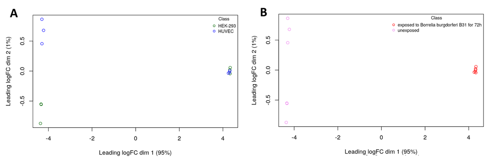

**Figure 1: MDS Plots of the normalized GSE194294 dataset.** [A] Plot based on cell line. [B] Plot based on treatment. [A, B] X-axis represents 95% of the variance in the samples while the y-axis represents 1% of the variance.

Due to the observed dominant effect of the treatment as compared to the cell lines, I decided to analyze the cell lines separately as the authors did in the original publication. Therefore, the differential expression analysis as well as other downstream analysis for this dataset will be conducted separately between the HUVEC and HEK-293 cell lines

## 3.2 Model Design

This dataset is simple and does not have many groups. Although below we find three rows (that are not the title), *cell line* and *cell type* actually refer to the same thing. Thus, this dataset only has two groups or factors: `cell line` and `treatment`.

**Table 1. Sample types for the Bb RNAseq Dataset**

```r
# Load the sample types dataframe from Assignment 1
load("RDataFromA1/sample_types.RData")
kable(t(sample_types[1, ]))
```

|  | GSM5832723 |
| --- | --- |
| title | AB34: HEK-293 control 72 h - rep1 |
| cell line | HEK-293 |
| cell type | human embryonic kidney cells |
| treatment | unexposed |

We start of by creating a simple model, which given the factors above, will create a matrix that represents our model. From the MDS plot, we know that treatment has a dominant effect and as previously mentioned, we separate the data by cell line so this leaves us with only `treatment` as the factor we can input to the model.

```r
# Separate samples by cell line
hek293_samples <- sample_types[1:6, ]
huvec_samples <- sample_types[7:12, ]

# Create model design for each cell line
hek293_model_design <- model.matrix(~hek293_samples$treatment)
huvec_model_design <- model.matrix(~huvec_samples$treatment)
```

**Table 2A. HEK293 Model Design Matrix**

```r
kable(hek293_model_design, row.names = TRUE)
```

|  | (Intercept) | hek293_samples$treatmentunexposed |
| --- | --- | --- |
| 1 | 1 | 1 |
| 2 | 1 | 1 |
| 3 | 1 | 1 |
| 4 | 1 | 0 |
| 5 | 1 | 0 |
| 6 | 1 | 0 |

**Table 2B. HUVEC Model Design Matrix**

```r
kable(huvec_model_design, row.names = TRUE)
```

|  | (Intercept) | huvec_samples$treatmentunexposed |
| --- | --- | --- |
| 1 | 1 | 1 |
| 2 | 1 | 1 |
| 3 | 1 | 1 |
| 4 | 1 | 0 |
| 5 | 1 | 0 |
| 6 | 1 | 0 |

We observe from that the two model design tables (Table 2AB) for the two cell lines are similar because they are both formatted the same way. Each cell has six samples with three replicates for each condition. The first three samples in both cell lines correspond to controls (as denoted by 1 in the `_$treatmentunexposed` column) while the last three correspond to those that were exposed to *B. burgdorferi*. These models will be used in the following section when fitting the model.

## 3.3 Fitting the Model

Before fitting the model, we subset the normalized data matrix so that we separate by cell lines.

```r
# Load the filtered matrix from A1 (Before Identifier Mapping)
load("RDataFromA1/filtered_data_matrix.RData")

# Rearrange columns so controls come first before treatment
hek293_matrix <- filtered_data_matrix[, c(10:12, 4:6)]
huvec_matrix <- filtered_data_matrix[, c(7:9, 1:3)]

# Remove version numbers in gene ids for mapping later
rownames(hek293_matrix) <- unlist(lapply(rownames(hek293_matrix),
                                         FUN=function(x){unlist(strsplit(x, split = "\\."))[1]}))
rownames(huvec_matrix) <- unlist(lapply(rownames(huvec_matrix),
                                         FUN=function(x){unlist(strsplit(x, split = "\\."))[1]}))
```

The *edgeR* [2] package contains many different models that can be used for differential expression. In this report, we used the **Quasi Likelihood (QL) Test** (`glmQLFTest`) which is highly recommended for bulk RNASeq experiments. Although the exactTest would be an appropriate method to use because the Bb RNAseq dataset uses a model with only one factor, the Quasi Likelihood test is generally more preferable because it estimates variance better, is more robust to DE analysis, and controls for FDR better, reducing the number of false positives [2].

### 3.3.1 Multiple Hypothesis Testing

By default, the glmQLFTest uses the Benjamini-Hochberg (BH) method for multiple hypothesis testing. The BH correction controls for the false discovery rate (FDR), making it well suited for RNA-seq data where thousands of genes are tested simultaneously [5]. Another method used in multiple hypothesis testing is the Bonferroni correction method. However, it is more stringent and highly conservative which greatly reduces the power to detect true positives. As such, BH correction was chosen as the method for multiple hypothesis testing in our analysis of finiding DE genes.

### 3.3.2 HEK293 QL Fitting and Testing

The coefficent for the QLF test is specified as `hek293_samples$treatmentunexposed` which is the second column in the model design matrix after `(Intercept)` (Table 2A). By setting this as the coefficient, we are looking at the differential expression between unexposed (control) and treatment (*B. burgdorferi* exposure).

**Table 3A. Top 10 Differentially Expressed Genes in HEK293**

```r
# Create an edgeR container
hek293_container <- DGEList(counts = hek293_matrix, group = hek293_samples$treatment)

# Normalize dataset
hek293_container <- calcNormFactors(hek293_container)

# Estimate dispersion
hek293_container <- estimateDisp(hek293_container, hek293_model_design)

# Fit to model
hek293_fit <- glmQLFit(hek293_container, hek293_model_design)

# Calculate DE using Quasi Likelihood model
qlf_hek293 <- glmQLFTest(hek293_fit, coef = "hek293_samples$treatmentunexposed")

kable(topTags(qlf_hek293), digits = 15)
```

|  | logFC | logCPM | F | PValue | FDR |
| --- | --- | --- | --- | --- | --- |
| ENSG00000118523 | 1.2027551 | 6.364450 | 786.3790 | 0.00000e+00 | 7.602000e-12 |
| ENSG00000142871 | 0.8640902 | 5.989735 | 419.5346 | 9.90000e-14 | 8.215720e-10 |
| ENSG00000111799 | 0.7319407 | 6.499792 | 362.2514 | 3.42000e-13 | 1.892908e-09 |
| ENSG00000128422 | 0.8543986 | 4.987842 | 340.6507 | 5.73000e-13 | 2.337390e-09 |
| ENSG00000148677 | 1.3626784 | 4.079714 | 332.4429 | 7.03000e-13 | 2.337390e-09 |
| ENSG00000006327 | 0.8007653 | 5.173218 | 304.1104 | 1.48200e-12 | 4.105277e-09 |
| ENSG00000149591 | 1.0288431 | 4.251973 | 236.4035 | 1.19630e-11 | 2.840472e-08 |
| ENSG00000283907 | 0.7026684 | 6.330363 | 208.8268 | 3.30570e-11 | 6.867613e-08 |
| ENSG00000170421 | 0.3473799 | 9.081540 | 146.4742 | 5.72433e-10 | 1.057092e-06 |
| ENSG00000130635 | 0.4681794 | 6.851925 | 142.7678 | 7.00914e-10 | 1.164920e-06 |

| x |
| --- |
| BH |

| x |
| --- |
| hek293_samples$treatmentunexposed |

| x |
| --- |
| glm |

### 3.3.3 HUVEC QL Fitting and Testing

Similarly, we apply the same method to the HUVEC cell line. The coefficient is set to `huvec_samples$treatmentunexposed` (Table 2B).

**Table 3B. Top 10 Differentially Expressed Genes in HUVEC**

```r
# Create an edgeR container
huvec_container <- DGEList(counts = huvec_matrix, group = huvec_samples$treatment)

# Normalize dataset
huvec_container <- calcNormFactors(huvec_container)

# Estimate dispersion
huvec_container <- estimateDisp(huvec_container, huvec_model_design)

# Fit to model
huvec_fit <- glmQLFit(huvec_container, huvec_model_design)

# Calculate DE using Quasi Likelihood model
qlf_huvec <- glmQLFTest(huvec_fit, coef = "huvec_samples$treatmentunexposed")

kable(topTags(qlf_huvec), digits = 15)
```

|  | logFC | logCPM | F | PValue | FDR |
| --- | --- | --- | --- | --- | --- |
| ENSG00000111335 | -4.362560 | 6.509962 | 773.6981 | 4.030e-13 | 2.708064e-09 |
| ENSG00000157601 | -5.445997 | 7.587499 | 770.3031 | 4.150e-13 | 2.708064e-09 |
| ENSG00000137959 | -5.467253 | 6.279353 | 722.1299 | 6.310e-13 | 2.708064e-09 |
| ENSG00000126709 | -4.120697 | 7.297222 | 706.9255 | 7.240e-13 | 2.708064e-09 |
| ENSG00000137965 | -3.173262 | 5.397595 | 677.6744 | 9.530e-13 | 2.708064e-09 |
| ENSG00000132530 | -3.249662 | 6.049163 | 675.0309 | 9.780e-13 | 2.708064e-09 |
| ENSG00000165949 | -3.148963 | 7.789598 | 596.5706 | 2.178e-12 | 5.172035e-09 |
| ENSG00000187608 | -3.081449 | 6.648371 | 577.3307 | 2.693e-12 | 5.337631e-09 |
| ENSG00000089127 | -3.723756 | 5.418763 | 571.0735 | 2.890e-12 | 5.337631e-09 |
| ENSG00000111331 | -2.663657 | 7.262363 | 545.0788 | 3.906e-12 | 6.492507e-09 |

| x |
| --- |
| BH |

| x |
| --- |
| huvec_samples$treatmentunexposed |

| x |
| --- |
| glm |

## 3.4 Significant Differentially Expressed Genes.

### 3.4.1 Thresholds

P-values were considered at a threshold of 0.05 to initially assess statistical significance while a significance threshold of FDR < 0.05 was used to identify DE genes. The FDR-adjusted values were prioritized rather than p-values because they account for multiple hypothesis testing. The threshold of 0.05 was chosen for both metrics because it is widely accepted in RNA-seq studies. This threshold effectively controls the false discovery rate by ensuring that on average, 5% of identified DE genes are false positive [6].

```r
# Top hits in HEK293
qlf_hits_hek293 <- topTags(qlf_hek293,
                           sort.by = "PValue",
                           n = nrow(hek293_matrix))

# Count DE Genes in HEK293 passing thresholds
hek293_pval <- length(which(qlf_hits_hek293$table$PValue < 0.05))
hek293_fdr <- length(which(qlf_hits_hek293$table$FDR < 0.05))

# Top hits in HUVEC
qlf_hits_huvec <- topTags(qlf_huvec,
                           sort.by = "PValue",
                           n = nrow(huvec_matrix))

# Count DE Genes in HUVEC passing thresholds
huvec_pval <- length(which(qlf_hits_huvec$table$PValue < 0.05))
huvec_fdr <- length(which(qlf_hits_huvec$table$FDR < 0.05))
```

### 3.4.2 MA Plot

The MA plot provides an overview of the overall distribution of gene expression changes which helps us in visually inspecting the spread of log-fold changes against the average expression level. We create this plot first as it highlights the general trend in our dataset and shows the biologically relevant DE genes.

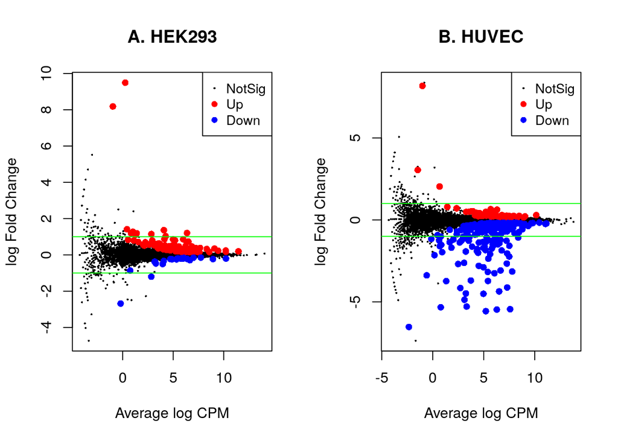

```r
# Create the MA plot function based on the plotMD function from edgeR
createMAplot <- function(qlf_hits, title) {
  plotMD(qlf_hits,
         main = title,
         xlab = "Average log CPM",
         ylab = "log Fold Change")
  abline(h=c(-1, 1), col="green")
}

# Do the plots side by side
par(mfrow = c(1, 2))

# Create MA plots
createMAplot(qlf_hek293, "A. HEK293")
createMAplot(qlf_huvec, "B. HUVEC")
```

```r
# Return plotting to normal
par(mfrow = c(1, 1))
```

From Fig. 2, we observe a noticeable difference in the general trends of both cell lines. HEK293 exhibits a greater proportion of DE genes that are upregulated, whereas HUVEC predominantly shows downregulated genes. Although there are many genes that are statistically significant in both cell lines, most of these do not meet the threshold for biological significance, i.e., they do not have log fold changes above the ±1 cutoff, suggesting that while these genes may be influenced by treatment or condition, the magnitude of their change may not be biologically relevant.

A key distinction is that HUVEC shows a significantly higher number of genes that are both statistically significant and biologically relevant (log fold change > ±1) compared to HEK293, indicating that HUVEC’s response to treatment may involve a more pronounced biological effect. This may suggest a stronger or more consistent gene expression alteration in response to the experimental condition in HUVEC.

### 3.4.3 Volcano Plot

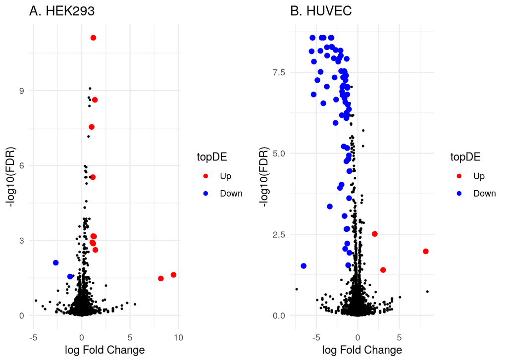

```r
createVolcano <- function(qlf_hits, title){
  qlfTable <- qlf_hits$table
  qlfTable$topDE <- "NA"

  qlfTable$topDE[qlfTable$logFC > 1 & qlfTable$FDR < 0.05] <- "Up"
  qlfTable$topDE[qlfTable$logFC < -1 & qlfTable$FDR < 0.05] <- "Down"

  ggplot(data=qlfTable, aes(x=logFC, y=-log10(FDR), color = topDE)) +
    geom_point(aes(size = ifelse(topDE == "NA", 0.5, 2))) +
    theme_minimal() +
    scale_colour_discrete(type = c("blue", "black", "red"), breaks = c("Up", "Down")) +
    scale_size_continuous(range = c(0.5, 2), guide="none") +
    labs(title = title, x = "log Fold Change", y = "-log10(FDR)")
}

# Create Volcano plots
hek293_volcPlot <- createVolcano(qlf_hits_hek293, "A. HEK293")
huvec_volcPlot <- createVolcano(qlf_hits_huvec, "B. HUVEC")

# Do the plots side by side
grid.arrange(hek293_volcPlot, huvec_volcPlot, ncol = 2)
```

**Figure 3. Volcano plot of differential gene expression between control and treatments in the Bb dataset.** [A] HEK293 cells. [B] HUVEC cells. Significant DE genes are determined from a threshold of FDR < 0.05 and a log fold change of ±1. Genes are colored red if upregulated and blue if downregulated. Genes that are not significant are colored black.

From Fig. 3, we further explore the relationship between the magnitude of gene expression changes (lo2 fold change) and their statistical significance (FDR) for both HEK293 and HUVEC cell lines. The volcano plot clearly highlights genes with both large log fold changes and significant FDR values.

In HEK293, only a small subset of statistically significant genes surpass the biological significance threshold of ±1 log fold change, as indicated by the lack of substantial DE genes compared to HUVEC. In contrast, HUVEC shows a more prominent clustering of genes with both high significance and large fold changes, reinforcing the earlier observation from the MA plot that HUVEC has a more robust biological response to treatment, with more genes exhibiting biologically relevant changes in expression. Of note, most of the DE genes in HUVEC are downregulated whereas HEK293 is prominently upregulated.

This volcano plot complements the MA plot by providing a more direct visualization of how both significance and biological relevance are distributed across the Bb dataset, underscoring the cell line specific response to the experimental condition *B. burgdorferi* exposure.

### 3.4.4 Heatmaps

Compared to the previous plots, a heatmap is a more detailed visualization which displays the expression of top DE genes across the samples. With this information, we can observe patterns in both gene and sample clustering which can help us confirm the biological significance of our findiungs on DE genes.

- Note that we also use the normalized counts matrix of the Bb dataset when generating the heatmaps, whereas the previous plots did not use this matrix. The difference in this matrix is that it has been transformed to counts per million.

```r
# Col 1 is the ensembl_gene_id and col 2 is the hgnc_symbol
load("RDataFromA1/normalized_counts_annot.RData")

# HEK293
hmap_matrix_hek293 <- normalized_counts_annot[, c(12:14, 6:8)]
rownames(hmap_matrix_hek293) <- normalized_counts_annot[, 1]

top_hits_hek293 <- rownames(qlf_hits_hek293$table)[
  qlf_hits_hek293$table$PValue<0.05]

hmap_tophits_hek293 <- t(scale(t(hmap_matrix_hek293[
  which(rownames(hmap_matrix_hek293) %in% top_hits_hek293),])))

# HUVEC
hmap_matrix_huvec <- normalized_counts_annot[, c(9:11, 3:5)]
rownames(hmap_matrix_huvec) <- normalized_counts_annot[, 1]

top_hits_huvec <- rownames(qlf_hits_huvec$table)[
  qlf_hits_huvec$table$PValue<0.05]

hmap_tophits_huvec <- t(scale(t(hmap_matrix_huvec[
  which(rownames(hmap_matrix_huvec) %in% top_hits_huvec),])))
```

- To make the heatmap more understandable, we also add annotations on which treatments the samples belongs.
- Note that this is the only factor left for our samples because we already separated them by cell lines.

```r
createHeatmap <- function(hmap_tophits, title){
  if(min(hmap_tophits) == 0){
    heatmap_col = colorRamp2(c( 0, max(hmap_tophits)),c( "white", "red"))
    } else {
      heatmap_col = colorRamp2(c(min(hmap_tophits), 0,
                                 max(hmap_tophits)), c("blue", "white", "red"))
      }
  hmap_annot <- HeatmapAnnotation(Treatment = factor(c(rep("Control", 3),
                                                       rep("Bb exposure", 3))),
                                  col = list(Treatment = c("Control" = "green",
                                                           "Bb exposure" = "yellow")))

  current_heatmap <- Heatmap(as.matrix(hmap_tophits),
                             cluster_rows = TRUE,
                             cluster_columns = TRUE,
                             show_row_dend = TRUE,
                             show_column_dend = TRUE,
                             col=heatmap_col,
                             show_column_names = FALSE,
                             show_row_names = FALSE,
                             show_heatmap_legend = TRUE,
                             top_annotation = hmap_annot,
                             column_title = title)

  return(current_heatmap)
}
```

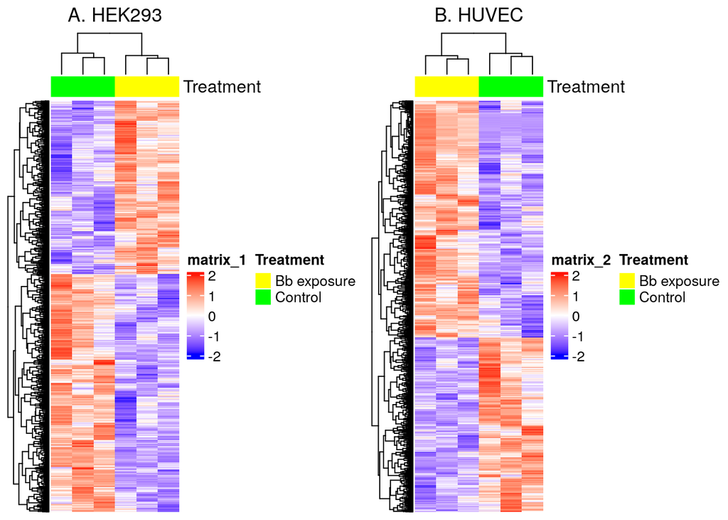

```r
# Create heatmaps
hek293_hmap <- grid.grabExpr(
  print(createHeatmap(hmap_tophits_hek293, title = "A. HEK293")))
huvec_hmap <- grid.grabExpr(
  print(createHeatmap(hmap_tophits_huvec, title = "B. HUVEC")))

# Do the plots side by side
grid.arrange(hek293_hmap, huvec_hmap, ncol = 2)
```

As evident in the clustering patterns of the columns in Fig. 4, samples cluster together by condition (treatment vs. control) in both cell lines. This observation indicates that within each cell line, gene expression patterns are altered by the experimental condition which in this case is *B. burgdorferi* exposure. This clustering of samples occur because the treatment induces similar responses across biological replicates while control samples maintain their baseline expression levels.

Similarly, we observe that genes are clustered as we observe distinct regions of upregulation (red) and downregulation (blue) with minimal mixing which indicates that certain groups of genes show coordinated changes in expression, likely due to common regulatory mechanisms or involvement in related pathways. Although the heatmap shows clear expressions patterns, we cannot directly conclude that the same genes are up- or downregulates between HEK293 and HUVEC without further analysis that identifies the specific genes. However, since we do observe that similar clustering appears in both heatmaps, this can indicate that a subset of the genes respond similarly to the treatment across cell types while others may show cell-type specific expression changes.

# 4 Thresholded Over-Representation Analysis

Over-Representation Analysis (ORA) is a statistical approach used to identify gene sets that are significantly enriched in a given gene list. In thresholded ORA, only genes that pass a specific significance threshold are included in the analysis.

## 4.1 Creating Gene Lists

```r
# Merge gene names with the top hits
hek293_qlf_hgnc <- merge(normalized_counts_annot[,1:2], qlf_hits_hek293, by.x=1, by.y = 0)
huvec_qlf_hgnc <- merge(normalized_counts_annot[,1:2], qlf_hits_huvec, by.x=1, by.y = 0)

# Upregulated Gene Set
hek293_up_genes <- hek293_qlf_hgnc$hgnc_symbol[which(hek293_qlf_hgnc$PValue < 0.05 & hek293_qlf_hgnc$logFC > 1)]
huvec_up_genes <- huvec_qlf_hgnc$hgnc_symbol[which(huvec_qlf_hgnc$PValue < 0.05 & huvec_qlf_hgnc$logFC > 1)]

# Downregulated Gene Set
hek293_down_genes <- hek293_qlf_hgnc$hgnc_symbol[which(hek293_qlf_hgnc$PValue < 0.05 & hek293_qlf_hgnc$logFC < -1)]
huvec_down_genes <- huvec_qlf_hgnc$hgnc_symbol[which(huvec_qlf_hgnc$PValue < 0.05 & huvec_qlf_hgnc$logFC < -1)]

# Combined Gene Set
hek293_combined <- unique(c(hek293_up_genes, hek293_down_genes))
huvec_combined <- unique(c(huvec_up_genes, huvec_down_genes))

# BH-Corrected Gene Set
hek293_fdr_genes <- hek293_qlf_hgnc$hgnc_symbol[which(hek293_qlf_hgnc$PValue < 0.05 & hek293_qlf_hgnc$FDR < 0.05 & hek293_qlf_hgnc$hgnc_symbol %in% hek293_combined)]
huvec_fdr_genes <- huvec_qlf_hgnc$hgnc_symbol[which(huvec_qlf_hgnc$PValue < 0.05 & huvec_qlf_hgnc$FDR < 0.05 & huvec_qlf_hgnc$hgnc_symbol %in% huvec_combined)]

hek293_up_genes["TGFBI"] <- "TGFB1"
hek293_combined["TGFBI"] <- "TGFB1"
hek293_fdr_genes["TGFBI"] <- "TGFB1"
```

## 4.2 Running g:Profiler through gprofiler2

To perform ORA, we use **gprofiler2** which is the R implementation of the web-based tool, g:Profiler. This method was chosen because unlike other implemented ORA tools, g:Profiler has regular updates on gene annotations, ensuring that the analysis reflects the most current biological knowledge. Additionally, g:Profiler integrates multiple annotation databases that are able to provide a broad scope for functional insights. Although the web-based version of g:Profiler could have been used for this analysis, the programmatic access provided by gprofiler2 makes it easier for us to integrate it in our workflow as everything else we have conducted has been performed in R.

```r
performORA <- function(query_set){
  gprofiler_results <- gost(query = query_set ,
                          significant = TRUE,
                          ordered_query = FALSE,  # query not ordered by significance
                          exclude_iea=TRUE,
                          correction_method = "fdr",
                          organism = "hsapiens",
                          evcodes = TRUE,
                          source = c("REAC", "GO:BP"))

  enrichment_results <- gprofiler_results$result

  return(enrichment_results)
}
```

## 4.3 Selected Annotation Databases

Since the Bb dataset aims to analyze *B. burgdorferi* exposure to human cells, we selected databases that capture immune response, signalling pathways, and cellular processes relevant to host-pathogen interactions.

```r
versions <- get_version_info(organism = "hsapiens")
versions$sources$`GO:BP`
```

```
## $name
## [1] "biological process"
##
## $version
## [1] "annotations: BioMart\nclasses: releases/2024-10-27"
```

```r
versions$sources$`REAC`
```

```
## $name
## [1] "Reactome"
##
## $version
## [1] "annotations: BioMart\nclasses: 2025-2-3"
```

The original publication only used Reactome, but selecting GO:BP also allows us to see the specific functional processes that are affected by the treatment.

## 4.4 Combined Gene Set ORA

We start performing ORA by combining all the significant DE genes discovered in both cell lines.

- **HEK293 Combined**

```r
hek293_ora <- performORA(hek293_combined)
```

```
## No results to show
## Please make sure that the organism is correct or set significant = FALSE
```

The combined gene set (n = 49) did not result to any enriched pathways for HEK293 perhaps because the signal has been diluted as it exhibits direction-specific enrichment patterns (only up or down).

- **HUVEC Combined**

```r
huvec_ora <- performORA(huvec_combined)
```

Surprisingly, the combined gene set for HUVEC yielded 220 results across all the annotation sources. This is not surprising, because we have almost triple the number of genes (n = 142) in HUVEC than in HEK293. The more the number of genes that we have, the more chances they are overrepresented in a gene set. To make the result more specific, it is filtered for a narrower range of term size e.g. between 5 and 200.

```r
huvec_ora_filtered <- huvec_ora[huvec_ora$term_size > 5 & huvec_ora$term_size < 200, ]
```

After filtering, the annotations were narrowed down to 118 which removed the overly broad or highly specific terms. We then show the top ten terms based on p-value and separated by annotation source. Since the p-values of the results are extremely small, separating them by source allows us us to see all the top terms depending on the context (Reactome for pathways and GO:BP for broader biological processes). Additionally, this approach prevents one source from dominating the results. Therefore, moving forward, all the top annotations will be shown as one table with 10 genes. The top 5 are from GO:BP while the bottom 5 are from Reactome.

```r
processAnnot <- function(ora_result) {
  ora_sorted <- ora_result[order(ora_result$p_value), ]
  selectCol <- ora_sorted[, c("term_name", "p_value", "intersection_size", "source")]

  gobp <- head(selectCol[selectCol$source == "GO:BP", ], n = 5)
  reac <- head(selectCol[selectCol$source == "REAC", ], n = 5)

  kable(rbind(gobp, reac), row.names = FALSE, digits = 40)
}
```

**Table 4. Top Enriched Pathways and Biological Processes Identified by ORA in HUVEC Combined Gene Set**

```r
processAnnot(huvec_ora_filtered)
```

| term_name | p_value | intersection_size | source |
| --- | --- | --- | --- |
| negative regulation of viral process | 2.210308e-19 | 17 | GO:BP |
| negative regulation of viral genome replication | 6.662069e-18 | 14 | GO:BP |
| regulation of viral process | 1.765135e-16 | 18 | GO:BP |
| regulation of viral genome replication | 2.232938e-15 | 14 | GO:BP |
| regulation of viral life cycle | 7.689143e-15 | 16 | GO:BP |
| Interferon alpha/beta signaling | 5.154990e-35 | 25 | REAC |
| Antiviral mechanism by IFN-stimulated genes | 3.921540e-11 | 14 | REAC |
| Interferon gamma signaling | 9.394511e-10 | 11 | REAC |
| ISG15 antiviral mechanism | 1.542986e-09 | 10 | REAC |
| OAS antiviral response | 7.101284e-08 | 5 | REAC |

## 4.5 Upregulated Gene Set

```r
performORA(hek293_up_genes)
```

```
##      query significant    p_value term_size query_size intersection_size
## 1  query_1        TRUE 0.04328926         2         11                 1
## 2  query_1        TRUE 0.04328926         6         11                 1
## 3  query_1        TRUE 0.04328926         6         11                 1
## 4  query_1        TRUE 0.04328926         3         11                 1
## 5  query_1        TRUE 0.04328926         4         11                 1
## 6  query_1        TRUE 0.04328926         7         11                 1
## 7  query_1        TRUE 0.04328926         5         11                 1
## 8  query_1        TRUE 0.04328926         7         11                 1
## 9  query_1        TRUE 0.04328926         5         11                 1
## 10 query_1        TRUE 0.04328926         4         11                 1
## 11 query_1        TRUE 0.04328926         3         11                 1
## 12 query_1        TRUE 0.04328926         2         11                 1
## 13 query_1        TRUE 0.04328926        95         11                 2
## 14 query_1        TRUE 0.04591859         8         11                 1
```

[output cut: 49 more lines]

```r
performORA(huvec_up_genes)
```

```
## No results to show
## Please make sure that the organism is correct or set significant = FALSE
```

## 4.6 Downregulated Gene Set ORA

HEK293 had 16 (7 novel) while HUVEC had 109 (13 novel). Since HEK293 has fewer genes (even fewer than the upregulated genes), we don’t expect to see much annotations for it. HUVEC, on the other hand has a lot of downregulated genes which is around triple the size of its upregulated genes. Thus, we expect to see a lot of annotations for this gene set.

```r
hek293_ora <- performORA(hek293_down_genes)
huvec_ora <- performORA(huvec_down_genes)
```

**Table 5. Top Enriched Pathways and Biological Processes Identified by ORA in HEK293 Downregulated Gene Set**

```r
processAnnot(hek293_ora)
```

| term_name | p_value | intersection_size | source |
| --- | --- | --- | --- |
| de novo centriole assembly | 0.04886636 | 1 | GO:BP |
| positive regulation of anaphase-promoting complex-dependent catabolic process | 0.04886636 | 1 | GO:BP |
| regulation of anaphase-promoting complex-dependent catabolic process | 0.04886636 | 1 | GO:BP |
| regulation of apoptotic process involved in development | 0.04886636 | 1 | GO:BP |
| positive regulation of apoptotic process involved in development | 0.04886636 | 1 | GO:BP |

**Table 6. Top Enriched Pathways and Biological Processes Identified by ORA in HUVEC Downregulated Gene Set**

```r
huvec_ora_filtered <- huvec_ora[huvec_ora$term_size > 5 & huvec_ora$term_size < 200, ]
processAnnot(huvec_ora_filtered)
```

| term_name | p_value | intersection_size | source |
| --- | --- | --- | --- |
| negative regulation of viral process | 4.271420e-21 | 17 | GO:BP |
| negative regulation of viral genome replication | 2.637172e-19 | 14 | GO:BP |
| regulation of viral process | 2.709810e-18 | 18 | GO:BP |
| regulation of viral genome replication | 8.681238e-17 | 14 | GO:BP |
| regulation of viral life cycle | 2.183875e-16 | 16 | GO:BP |
| Interferon alpha/beta signaling | 2.148000e-37 | 25 | REAC |
| Antiviral mechanism by IFN-stimulated genes | 2.439524e-12 | 14 | REAC |
| Interferon gamma signaling | 1.030664e-10 | 11 | REAC |
| ISG15 antiviral mechanism | 2.028035e-10 | 10 | REAC |
| OAS antiviral response | 2.274428e-08 | 5 | REAC |

Since we also got a lot of annotations for the downregulated genes of HUVEC, we also filter it by term size; after which, we get 144 annotations. Notice that these annotations are the same as what we got in the top annotations from the HUVEC combined gene set. This is not surprising at all because the combined gene set was dominated by down regulated genes so it made sense that the annotations also came from these set.

## 4.7 BH-Corrected Gene Set ORA

Finally, we investigate to see if any of the annotations above survive multiple hypothesis testing. Since we did not got any useful annotations for the HEK293 gene sets, we do not expect to see annotations here as well, but we will still perform it nevertheless. In contrast, we expect to see many annotations for HUVEC since it does have a lot of downregulated genes.

```r
hek293_ora <- performORA(hek293_fdr_genes)
processAnnot(hek293_ora)
```

| term_name | p_value | intersection_size | source |
| --- | --- | --- | --- |
| tissue development | 0.03209314 | 6 | GO:BP |
| cardiac muscle tissue development | 0.03314419 | 3 | GO:BP |
| muscle tissue development | 0.03624903 | 3 | GO:BP |
| cardiac muscle tissue morphogenesis | 0.03624903 | 2 | GO:BP |
| positive regulation of secretion | 0.03624903 | 3 | GO:BP |
| SMAD2/3 Phosphorylation Motif Mutants in Cancer | 0.02113253 | 1 | REAC |
| Loss of Function of SMAD2/3 in Cancer | 0.02113253 | 1 | REAC |
| Loss of Function of TGFBR1 in Cancer | 0.02113253 | 1 | REAC |
| Loss of Function of TGFBR2 in Cancer | 0.02113253 | 1 | REAC |
| RUNX3 regulates CDKN1A transcription | 0.02113253 | 1 | REAC |

```r
hek293_ora_filtered <- hek293_ora[hek293_ora$term_size > 5 & hek293_ora$term_size < 200, ]
hek293_ora_filtered
```

```
##      query significant    p_value term_size query_size intersection_size
## 2  query_1        TRUE 0.03314419       140         10                 3
## 4  query_1        TRUE 0.03624903        44         10                 2
## 6  query_1        TRUE 0.03624903        49         10                 2
## 7  query_1        TRUE 0.03624903       182         10                 3
## 8  query_1        TRUE 0.03624903        49         10                 2
## 9  query_1        TRUE 0.03624903        36         10                 2
## 25 query_1        TRUE 0.02113253         6          6                 1
## 26 query_1        TRUE 0.02113253         6          6                 1
## 28 query_1        TRUE 0.02113253         7          6                 1
## 30 query_1        TRUE 0.02113253         7          6                 1
## 31 query_1        TRUE 0.02113253        95          6                 2
## 36 query_1        TRUE 0.02228856         8          6                 1
## 37 query_1        TRUE 0.02327825         9          6                 1
## 38 query_1        TRUE 0.03375789        14          6                 1
```

[output cut: 65 more lines]

**Table 7. Top Enriched Pathways and Biological Processes Identified by ORA in HUVEC Adjusted Gene Set**

```r
huvec_ora <- performORA(huvec_fdr_genes)
huvec_ora_filtered <- huvec_ora[huvec_ora$term_size > 5 & huvec_ora$term_size < 200, ]
processAnnot(huvec_ora_filtered)
```

| term_name | p_value | intersection_size | source |
| --- | --- | --- | --- |
| negative regulation of viral process | 8.721804e-23 | 17 | GO:BP |
| negative regulation of viral genome replication | 1.099912e-20 | 14 | GO:BP |
| regulation of viral process | 4.995598e-20 | 18 | GO:BP |
| regulation of viral genome replication | 3.452715e-18 | 14 | GO:BP |
| regulation of viral life cycle | 5.694054e-18 | 16 | GO:BP |
| Interferon alpha/beta signaling | 1.800000e-39 | 25 | REAC |
| Antiviral mechanism by IFN-stimulated genes | 2.451854e-13 | 14 | REAC |
| Interferon gamma signaling | 1.724141e-11 | 11 | REAC |
| ISG15 antiviral mechanism | 3.985795e-11 | 10 | REAC |
| OAS antiviral response | 9.755497e-09 | 5 | REAC |

```r
huvec_ora
```

[output not shown]

[output cut: 2055 more lines]

As expected, the annotations we got for the downregulated gene set of HUVEC were able to pass multiple hypothesis testing which means that these results are more likely to reflect a true biological signal